# Armando TF curso

Guillermo Quina y Soledad González Alvarisqueta

2025-03-05

# **Trabajo Práctico Final**

En el siguiente informe, presentamos un análisis de la precariedad del mercado de trabajo en Argentina en la actualidad, de acuerdo con el análisis de la Encuesta Permanente de Hogares que publica el INDEC, a partir de los datos del tercer trimestre de 2024.

## **Selección de encuesta**

```
Elegir una encuesta de hogares relevada por el instituto nacional de
estadística oficial de algún país. *(Se puede elegir un país que esté en el
repositorio del proyecto Precariedad Mundial)*.
```

*Seleccionamos la EPH de Argentina para el tercer trimestre de 2024. Dicha selección se debe a que el tercer trimestre minimiza los efectos estacionales sobre el mercado de trabajo, en tanto el año 2024 es el último disponible para dicho período.*

*El procesamiento de los datos se llevó a cabo mediante el programa RStudio. Para ello, se conformó una base de datos con variables básicas (sexo, edad, región, etcétera) y otras específicas relacionadas con la dimensión laboral (condición de ocupación, multiempleo, cantidad de horas trabajadas, etcétera).*

```r
## PRIMER PASO, CARGAMOS LAS BIBLIOTECAS QUE UTILIZAREMOS PARA PROCESAR, CREAR TABLAS, GRÁFICOS Y TABLETROS

library(tidyverse)
library(openxlsx)
library(eph)
library(scales)
library(dplyr)
library(knitr)
library(kableExtra)
library(htmltools)
library(writexl)
```

```r
library(ggplot2)
library(flexdashboard)
library(plotly)
library(janitor)
## SEGUNDO PASO: ELEGIMOS UNA BASE DE DATOS (EPH, TERCER TRIMESTRE 2024) Y LA LEVANTAMOS CON EL PAQUETE EPH, A EFECTOS DE GENERAR UNA BASE DE DATOS SEGUN LAS VARIABLES QUE HEMOS PLANTEADO CONSIDERAR PARA TRABAJAR CON LA TEMÁTICA DE PRECARIEDAD.

variables <- c("CODUSU","NRO_HOGAR","COMPONENTE","ANO4","TRIMESTRE", "REGION", "AGLOMERADO", "CH03","CH04","CH06","ESTADO","CAT_OCUP","CAT_INAC", "PP03C", "PP03I", "PP04A", "PP04B_COD", "PP05H", "PP07H","P21","P47T","PONDERA","PP04D_COD","PP04C", "PP06E", "PP07A","PP07C","PP05B2_ANO","PP04B3_ANO","PP07E","NIVEL_ED","PONDIIO","PP04C","PP03G","PP3E_TOT")

eph_2024_t3 <-eph::get_microdata(year = 2024, period = 3, vars = variables)
```

## Mercado de trabajo

**Para un primer análisis exploratorio del mercado de trabajo identificamos los totales de la base según sexo, rangos etarios, condición y tipo de ocupación, nivel educactivo y percepción de ingresos.**

“Tabla_edad_y_sexo.html”

“Tabla_Cat_Ocup_Niv_Ed.html”

“Tabla_perceptores_region.html”

“Tabla_perceptores_edad.html”

```r
### Los grupos etarios conformados consideran especialmente la franja juvenil de la fuerza de trabajo (18 a 25 años) así como la edad jubilatoria de hombres y mujeres.
eph_2024_t3_grupos_edad <- eph_2024_t3 %>%
  filter(CH06 >= 10)  %>%
  mutate(Grupos_Etarios = case_when(CH06  %in%  10:17   ~ "Menores",
                                    CH06  %in%  18:25   ~ "Adultos Jóvenes",
                        CH04 == 1 & CH06 %in% 26:65 ~ "Adultos mediana edad" ,
                        CH04 == 2 & CH06 %in% 26:60 ~ "Adultos mediana edad",
                        CH04 == 1 & CH06 > 65 ~ "Adultos Mayores",
                        CH04 == 2 & CH06 > 60 ~ "Adultos Mayores",
                                  is.na(CH06) ~ "No responde edad"))


eph_2024_t3_grupos_edad <- eph_2024_t3_grupos_edad %>%
  mutate(Sexo = case_when(CH04  == 1   ~ "Varón", CH04  == 2   ~ "Mujer"))


eph_2024_t3_grupos_edad <- eph_2024_t3_grupos_edad %>%
  mutate(Nivel_Educativo = case_when(NIVEL_ED  == 1   ~ "Primaria Incompleta",
                                 NIVEL_ED  == 2   ~ "Primaria Completa",
                                 NIVEL_ED  == 3   ~ "Secundaria Incompleta",
                                 NIVEL_ED  == 4   ~ "Secundaria Completa",
                                 NIVEL_ED  == 5   ~ "Superior Univ Incompleta",                                     NIVEL_ED  == 6   ~ "Superior Univ Completa",
                                 NIVEL_ED  == 7   ~ "Sin Instrucción"))


eph_2024_t3_grupos_edad <- eph_2024_t3_grupos_edad %>%
  mutate(Categ_ocup = case_when(CAT_OCUP  == 1   ~ "Patrón",
                                CAT_OCUP  == 2   ~ "Cuenta propia",
                                CAT_OCUP  == 3   ~ "Obrero o empleado",
                                CAT_OCUP  == 4   ~ "Trab fam sin remun"))


Base_por_grupos_edad_y_sexo <- calculate_tabulates(base = eph_2024_t3_grupos_edad,x = "Grupos_Etarios",y = "Sexo",weights = "PONDERA",add.totals = "both")

Base_por_cat_ocup <- calculate_tabulates(base = eph_2024_t3_grupos_edad,x = "Categ_ocup",y = "Nivel_Educativo",weights = "PONDERA",add.totals = "both")

## convertimos esta última a proporciones en porcentaje:

Base_por_cat_ocup <- data.frame(
  Categ_Ocup = c("Cuenta propia", "Obrero o empleado", "Patrón", "Trab fam sin remun"),
  Primaria_Completa = c(445360, 942935, 37863, 3769),
  Primaria_Incompleta = c(140498, 216581, 11312, 3940),
  Secundaria_Completa = c(944297, 3192672, 127558, 18454),
  Secundaria_Incompleta = c(619775, 1558282, 50325, 10139),
  Sin_Instruccion = c(13904, 14338, 303, 297),
  Superior_Univ_Completa = c(648006, 2833458, 158771, 822),
  Superior_Univ_Incompleta = c(474154, 1580701, 58776, 15344),
  Total = c(3285994, 10338967, 444908, 52765))

Base_por_cat_ocup <- Base_por_cat_ocup %>%
mutate(across(Primaria_Completa:Superior_Univ_Incompleta,
                ~ round((. / Total) * 100, 1)))

print(Base_por_cat_ocup)
```

```
##           Categ_Ocup Primaria_Completa Primaria_Incompleta Secundaria_Completa
## 1      Cuenta propia              13.6                 4.3                28.7
## 2  Obrero o empleado               9.1                 2.1                30.9
## 3             Patrón               8.5                 2.5                28.7
## 4 Trab fam sin remun               7.1                 7.5                35.0
##   Secundaria_Incompleta Sin_Instruccion Superior_Univ_Completa
## 1                  18.9             0.4                   19.7
## 2                  15.1             0.1                   27.4
## 3                  11.3             0.1                   35.7
## 4                  19.2             0.6                    1.6
##   Superior_Univ_Incompleta    Total
## 1                     14.4  3285994
## 2                     15.3 10338967
## 3                     13.2   444908
## 4                     29.1    52765
```

```r
##Creamos tablas para cruzar las variables edad y sexo, categoría ocupacional y nivel educativo, respectivamente

##TABLA 1

Tabla_edad_y_sexo <- kable(Base_por_grupos_edad_y_sexo, format = "html", caption = "Tabla 1: Base EPH 3er trimestre 2024 por edad según sexo", align = 'c')

Tabla_edad_y_sexo
```

Tabla 1: Base EPH 3er trimestre 2024 por edad según sexo

| Grupos_Etarios/Sexo | Mujer | Varón | Total |
| --- | --- | --- | --- |
| Adultos Jóvenes | 1779962 | 1826701 | 3606663 |
| Adultos Mayores | 2755204 | 1358482 | 4113686 |
| Adultos mediana edad | 6850985 | 7112827 | 13963812 |
| Menores | 1942445 | 2040332 | 3982777 |
| Total | 13328596 | 12338342 | 25666938 |

```r
##TABLA 2

Tabla_Cat_Ocup_Niv_Ed <- kable(Base_por_cat_ocup, format = "html", caption = "Tabla 2: Base EPH 3er trimestre 2024 por Categoría Ocupacional según nivel educativo", align = 'c')

Tabla_Cat_Ocup_Niv_Ed
```

Tabla 2: Base EPH 3er trimestre 2024 por Categoría Ocupacional según nivel educativo

| Categ_Ocup | Primaria_Completa | Primaria_Incompleta | Secundaria_Completa | Secundaria_Incompleta | Sin_Instruccion | Superior_Univ_Completa | Superior_Univ_Incompleta | Total |
| --- | --- | --- | --- | --- | --- | --- | --- | --- |
| Cuenta propia | 13.6 | 4.3 | 28.7 | 18.9 | 0.4 | 19.7 | 14.4 | 3285994 |
| Obrero o empleado | 9.1 | 2.1 | 30.9 | 15.1 | 0.1 | 27.4 | 15.3 | 10338967 |
| Patrón | 8.5 | 2.5 | 28.7 | 11.3 | 0.1 | 35.7 | 13.2 | 444908 |
| Trab fam sin remun | 7.1 | 7.5 | 35.0 | 19.2 | 0.6 | 1.6 | 29.1 | 52765 |

```r
##Exploramos las cantidades de perceptores de ingresos según sexo. Para ello, creamos la variable perceptor de ingresos (s_p) y la convertimos a factor. Luego la cruzaremos con las regiones de pertenencia.

eph_2024_t3_grupos_edad <- eph_2024_t3_grupos_edad %>%
  mutate(s_p = case_when(
  CH04 == 1 & P47T > 0 ~ "Varón perceptor",
  CH04 == 1 & P47T == 0 ~ "Varón no perceptor",
  CH04 == 2 & P47T > 0 ~ "Mujer perceptora",
  CH04 == 2 & P47T == 0 ~ "Mujer no perceptora",
  P47T== -9 ~ "No responde ingresos"))

s_p_niveles <- c("Varón perceptor", "Varón no perceptor", "Mujer perceptora", "Mujer no perceptora", "No responde ingresos")

# Convertir a factor con niveles específicos
eph_2024_t3_grupos_edad$s_p <- factor(eph_2024_t3_grupos_edad$s_p, levels = s_p_niveles, labels = c("Varón perceptor", "Varón no perceptor", "Mujer perceptora", "Mujer no perceptora", "No responde ingresos"))


# Mostramos el factor

tabulation <- calculate_tabulates(base = eph_2024_t3_grupos_edad, x = "s_p",
weights = "PONDERA")


tabulationcheck <- calculate_tabulates(base = eph_2024_t3_grupos_edad, x =
"CH04", weights = "PONDERA")


REGION_niveles <- c("1", "40", "41", "42", "43", "44")


# Convertimos a factor con niveles específicos
eph_2024_t3_grupos_edad$REGION <- factor(eph_2024_t3_grupos_edad$REGION, levels = REGION_niveles, labels=c("1", "40", "41", "42", "43", "44"))

Perceptores_segun_region <- calculate_tabulates(base = eph_2024_t3_grupos_edad, x = "s_p", y = "REGION", weights = "PONDERA", add.totals="both", add.percentage="col")


Perceptores_segun_region <- Perceptores_segun_region %>%
  rename ( "Gran Buenos Aires" = "1",
"NOA" = "40",
"NEA" = "41",
"Cuyo" = "42",
"Pampeana" = "43",
"Patagonia" = "44" )

eph_2024_t3_grupos_edad
```

```
## # A tibble: 41,963 × 39
##    CODUSU     NRO_HOGAR COMPONENTE  ANO4 TRIMESTRE REGION AGLOMERADO  CH03  CH04
##    <chr>          <int>      <int> <int>     <int> <fct>       <int> <int> <int>
##  1 TQRMNOPTV…         1          1  2024         3 43              3     1     2
##  2 TQRMNOPTV…         1          2  2024         3 43              3     2     1
##  3 TQRMNOQPR…         1          1  2024         3 43              3     1     1
##  4 TQRMNOQPR…         1          2  2024         3 43              3     2     2
##  5 TQRMNORVX…         1          1  2024         3 43              3     1     1
##  6 TQRMNORVX…         1          2  2024         3 43              3     2     2
##  7 TQRMNORVX…         1          3  2024         3 43              3     3     1
##  8 TQRMNQYTS…         1          1  2024         3 43              3     1     1
##  9 TQRMNQYTS…         1          2  2024         3 43              3     2     2
## 10 TQRMNQYTS…         1          3  2024         3 43              3     3     2
## # ℹ 41,953 more rows
## # ℹ 30 more variables: CH06 <int>, ESTADO <int>, CAT_OCUP <int>,
## #   CAT_INAC <int>, PP03C <int>, PP03I <int>, PP04A <int>, PP04B_COD <chr>,
## #   PP05H <int>, PP07H <int>, P21 <int>, P47T <int>, PONDERA <int>,
## #   PP04D_COD <chr>, PP04C <int>, PP06E <int>, PP07A <int>, PP07C <int>,
## #   PP05B2_ANO <int>, PP04B3_ANO <int>, PP07E <int>, NIVEL_ED <int>,
## #   PONDIIO <int>, PP03G <int>, PP3E_TOT <int>, Grupos_Etarios <chr>, …
```

```r
##Creamos una tabla de perceptores de ingresos según sexo y región
##TABLA 3


Tabla_perceptores_region <- kable(Perceptores_segun_region, format = "html", caption = "Tabla 3:
Distribución Cruzada por Regiones y Sexo Perceptor", align = 'c')

Tabla_perceptores_region
```

Tabla 3: Distribución Cruzada por Regiones y Sexo Perceptor

| s_p/REGION | Gran Buenos Aires | NOA | NEA | Cuyo | Pampeana | Patagonia | Total |
| --- | --- | --- | --- | --- | --- | --- | --- |
| Varón perceptor | 24.7 | 32.9 | 29.3 | 29.8 | 27.8 | 28.5 | 26.8 |
| Varón no perceptor | 12.1 | 12.6 | 12.9 | 12.0 | 11.7 | 14.6 | 12.2 |
| Mujer perceptora | 26.5 | 35.7 | 32.9 | 31.1 | 31.2 | 26.9 | 29.0 |
| Mujer no perceptora | 15.9 | 14.5 | 14.4 | 14.8 | 13.1 | 17.3 | 15.1 |
| No responde ingresos | 20.8 | 4.4 | 10.4 | 12.4 | 16.3 | 12.6 | 16.9 |
| Total | 100.0 | 100.0 | 100.0 | 100.0 | 100.0 | 100.0 | 100.0 |

```r
##Creamos una tabla para explorar percepción de ingresos según grupo etario
##TABLA 4

Tabla_perceptores_grupo_etario <- calculate_tabulates(base = eph_2024_t3_grupos_edad, x = "s_p", y = "Grupos_Etarios", weights = "PONDERA", add.totals="row", add.percentage="col")

Tabla_perceptores_edad <- kable(Tabla_perceptores_grupo_etario, format = "html", caption = "Tabla 4: Distribución cruzada por Grupos Etarios y Sexo Perceptor", align = 'c')

Tabla_perceptores_edad
```

Tabla 4: Distribución cruzada por Grupos Etarios y Sexo Perceptor

| s_p/Grupos_Etarios | Adultos Jóvenes | Adultos Mayores | Adultos mediana edad | Menores |
| --- | --- | --- | --- | --- |
| Varón perceptor | 22.0 | 24.9 | 35.5 | 2.7 |
| Varón no perceptor | 20.4 | 1.0 | 3.1 | 48.2 |
| Mujer perceptora | 21.2 | 50.7 | 32.2 | 2.6 |
| Mujer no perceptora | 22.1 | 3.3 | 8.0 | 45.8 |
| No responde ingresos | 14.3 | 20.1 | 21.2 | 0.7 |
| Total | 100.0 | 100.0 | 100.0 | 100.0 |

```r
##Guardamos las tablas creadas con kable:

save_html(Tabla_edad_y_sexo, file = "Tabla_edad_y_sexo.html")
save_html(Tabla_Cat_Ocup_Niv_Ed, file = "Tabla_Cat_Ocup_Niv_Ed.html")
save_html(Tabla_perceptores_region, file = "Tabla_perceptores_region.html")
save_html(Tabla_perceptores_edad, file = "Tabla_perceptores_edad.html")

writeLines(as.character(Tabla_edad_y_sexo), "tabla_clasificacion1.html")
writeLines(as.character(Tabla_Cat_Ocup_Niv_Ed), "tabla_clasificacion2.html")
writeLines(as.character(Tabla_perceptores_region), "tabla_clasificacion3.html")
writeLines(as.character(Tabla_perceptores_edad), "tabla_clasificacion4.html")
```

Asimismo, si bien la tasa de desempleo se mantiene por debajo de los 8 puntos porcentuales, e incluso en algunas regiones (Cuyo y Noroeste) es menor a 5%, el corte por grupos etarios muestra que el segmento de adultos jóvenes (18 a 25 años) más que duplica estos valores de desocupación, alcanzando un 18.5%.

“Tabla_Mercado_Trabajo.html”

“Tabla_Mercado_trabajo_sexo.html”

“Tabla_Mercado_trabajo_regiones.html”

```r
##Caracterización del mercado laboral


Mercado_trabajo <- eph_2024_t3_grupos_edad %>% group_by(REGION) %>%
summarize(
población = sum(PONDERA, na.rm = TRUE),
Ocupados = sum(PONDERA[ESTADO == 1], na.rm = TRUE),
desempleo_total = sum(PONDERA[ESTADO == 2], na.rm = TRUE),
PEA = Ocupados + desempleo_total,
PEI = población - PEA,
Tasa_actividad = round((PEA / población) * 100,1),
Tasa_empleo = round((Ocupados / población)* 100,1),
Tasa_desocupados = round((desempleo_total / PEA) * 100,1) )


Mercado_trabajo_sexo <- eph_2024_t3_grupos_edad %>% group_by(Sexo) %>%
summarize( población = sum(PONDERA, na.rm = TRUE),
Ocupados = sum(PONDERA[ESTADO == 1], na.rm = TRUE),
desempleo_total = sum(PONDERA[ESTADO == 2], na.rm = TRUE),
PEA = Ocupados + desempleo_total,
PEI = población - PEA,
Tasa_actividad = round((PEA / población) * 100,1),
Tasa_empleo = round((Ocupados / población)* 100,1),
Tasa_desocupados = round((desempleo_total / PEA) * 100,1) )%>%
ungroup()

Mercado_trabajo_sexo
```

```
## # A tibble: 2 × 9
##   Sexo  población Ocupados desempleo_total     PEA     PEI Tasa_actividad
##   <chr>     <int>    <int>           <int>   <int>   <int>          <dbl>
## 1 Mujer  13328596  5889957          504028 6393985 6934611           48
## 2 Varón  12338342  7478083          490306 7968389 4369953           64.6
## # ℹ 2 more variables: Tasa_empleo <dbl>, Tasa_desocupados <dbl>
```

```r
Mercado_trabajo_edades <- eph_2024_t3_grupos_edad %>% group_by(Grupos_Etarios) %>%
summarize( población = sum(PONDERA, na.rm = TRUE),
Ocupados = sum(PONDERA[ESTADO == 1], na.rm = TRUE),
desempleo_total = sum(PONDERA[ESTADO == 2], na.rm = TRUE),
PEA = Ocupados + desempleo_total,
PEI = población - PEA,
Tasa_actividad = round((PEA / población) * 100,1),
Tasa_empleo = round((Ocupados / población)* 100,1),
Tasa_desocupados = round((desempleo_total / PEA) * 100,1) ) %>% ungroup()


Mercado_trabajo_Region <- eph_2024_t3_grupos_edad %>%
group_by(REGION) %>%
summarize(población = sum(PONDERA, na.rm = TRUE),
Ocupados = sum(PONDERA[ESTADO == 1], na.rm = TRUE),
desempleo_total = sum(PONDERA[ESTADO == 2], na.rm =TRUE),
PEA = Ocupados + desempleo_total,
PEI = población - PEA,
Tasa_actividad = round((PEA / población) * 100,1),
Tasa_empleo = round((Ocupados / población)* 100,1),
Tasa_desocupados = round((desempleo_total / PEA) * 100,1) )%>%
ungroup()

Mercado_trabajo_Region <- Mercado_trabajo_Region %>%
  mutate(REGION = case_when(
    REGION == 1   ~ "Gran Buenos Aires",
    REGION == 40  ~ "Noroeste",
    REGION == 41  ~ "Nordeste",
    REGION == 42  ~ "Cuyo",
    REGION == 43  ~ "Pampeana",
    REGION == 44  ~ "Patagonica"
  ))

Mercado_trabajo_Region
```

```
## # A tibble: 6 × 9
##   REGION         población Ocupados desempleo_total    PEA    PEI Tasa_actividad
##   <chr>              <int>    <int>           <int>  <int>  <int>          <dbl>
## 1 Gran Buenos A…  13776295  7305787          598845 7.90e6 5.87e6           57.4
## 2 Noroeste         2455957  1237347           54468 1.29e6 1.16e6           52.6
## 3 Nordeste         1268692   614574           35982 6.51e5 6.18e5           51.3
## 4 Cuyo             1608444   837050           42890 8.80e5 7.29e5           54.7
## 5 Pampeana         5579920  2896163          235176 3.13e6 2.45e6           56.1
## 6 Patagonica        977630   477119           26973 5.04e5 4.74e5           51.6
## # ℹ 2 more variables: Tasa_empleo <dbl>, Tasa_desocupados <dbl>
```

```r
##Generamos y guardamos las tablas en kable

Tabla_Mercado_Trabajo <- kable(Mercado_trabajo, format = "html", caption = "Tabla 5: Mercado de Trabajo", align = 'c')

Tabla_Mercado_trabajo_sexo <- kable(Mercado_trabajo_sexo, format = "html", caption = "Tabla 6: Mercado de Trabajo según sexo", align = 'c')

Tabla_Mercado_trabajo_edades <- kable(Mercado_trabajo_edades, format = "html", caption = "Tabla 7: Mercado de Trabajo según edades", align = 'c')

Tabla_Mercado_trabajo_regiones <- kable(Mercado_trabajo_Region, format = "html", caption = "Tabla 8: Mercado de Trabajo según regiones", align = 'c')

save_html(Tabla_Mercado_Trabajo, file = "Tabla_Mercado_Trabajo.html")
save_html(Tabla_Mercado_trabajo_sexo, file = "Tabla_Mercado_trabajo_sexo.html")
save_html(Tabla_Mercado_trabajo_edades, file = "Tabla_Mercado_trabajo_edades.html")
save_html(Tabla_Mercado_trabajo_regiones, file = "Tabla_Mercado_trabajo_regiones.html")

writeLines(as.character(Tabla_Mercado_Trabajo), "tabla_clasificacion5.html")
writeLines(as.character(Tabla_Mercado_trabajo_sexo), "tabla_clasificacion6.html")
writeLines(as.character(Tabla_Mercado_trabajo_edades), "tabla_clasificacion7.html")
writeLines(as.character(Tabla_Mercado_trabajo_regiones), "tabla_clasificacion8.html")
```

## Precariedad laboral

```r
##partimos de la base originalmente creada y volvemos a crear las variables de grupo etario y nivel educativo

eph_2024_t3 <- eph_2024_t3 %>% filter(CH06 >= 10)  %>%
  mutate(Grupos_Etarios = case_when(CH06  %in%  10:17   ~ "Menores",
                                    CH06  %in%  18:25   ~ "Adultos Jóvenes",
                                    CH06 %in% 26:39 ~ "Adultos mediana edad 1" ,
                                    CH06 %in% 40:49 ~ "Adultos mediana edad 2",
                        CH04 == 1 & CH06 %in% 50:65 ~ "Adultos mediana edad 3",
                        CH04 == 2 & CH06 %in% 50:60 ~ "Adultos mediana edad 3",
                        CH04 == 1 & CH06 > 65 ~ "Adultos Mayores",
                        CH04 == 2 & CH06 > 60 ~ "Adultos Mayores",
                                  is.na(CH06) ~ "No responde edad"))

eph_2024_t3 <- eph_2024_t3 %>%
  mutate(Sexo = case_when(CH04  == 1   ~ "Varón", CH04  == 2   ~ "Mujer"))


eph_2024_t3 <- eph_2024_t3 %>%
  mutate(Nivel_Educativo = case_when(NIVEL_ED  == 1   ~ "Primaria Incompleta",
                                 NIVEL_ED  == 2   ~ "Primaria Completa",
                                 NIVEL_ED  == 3   ~ "Secundaria Incompleta",
                                 NIVEL_ED  == 4   ~ "Secundaria Completa",
                                 NIVEL_ED  == 5   ~ "Superior Univ Incompleta",                                     NIVEL_ED  == 6   ~ "Superior Univ Completa",
                                 NIVEL_ED  == 7   ~ "Sin Instrucción"))


eph_2024_t3 <- eph_2024_t3 %>%
  mutate(Categ_ocup = case_when(CAT_OCUP  == 1   ~ "Patrón",
                                CAT_OCUP  == 2   ~ "Cuenta propia",
                                CAT_OCUP  == 3   ~ "Obrero o empleado",
                                CAT_OCUP  == 4   ~ "Trab fam sin remun"))

## filtramos ocupados y renombramos
ocupados_2024_t3 <- eph_2024_t3 %>%
  filter(ESTADO == 1, CAT_OCUP == 3 | 2)
```

### Propuesta de medición

Definimos a la **condición de precariedad** a partir de tres indicadores: **subocupacion involuntaria, informalidad y trabajo a término.** Esto se sostiene sobre la consideración de que la condición de precariedad en la actualidad se despliega de manera heterogénea sobre las dinámicas laborales de diferentes sectores y ocupaciones, por lo cual no necesariamente se iguala con la informalidad, la temporalidad o la insuficiente carga horaria, sino que éstos son elementos combinables que, a su vez, potencian sus efectos precarios entre sí.

Consideramos **factores agravantes** al **multiempleo** y la **ocupacion en establecimientos pequeños** (1 a 6 empleados), entendiendo que en sí mismos no constituyen elementos de la precariedad laboral, pero sí agravan la situación laboral precaria cuando ésta se encuentra presente.

Determinamos **tres niveles de precariedad** en atención a reconocer una gradiente de situaciones precarias cuando se cumplen una, dos o tres condiciones (condición laboral de **precariedad leve**, condición laboral **precaria media** y condición laboral **precaria severa** ).

En virtud de ello, generamos variables que reflejen el cumplimiento de esas condiciones: a) multiempleo; b) tamaño de establecimiento (pequeño/mediano/grande); c) informalidad (asalariada, cuando no hay descuento jubilatorio e independiente, si la empresa no está juridicamente constituida); d) empleo de medio tiempo involuntario (menos de 35hs); e) empleo con tiempo determinado.

```r
ocupados_2024_t3_indicadores_prec <-ocupados_2024_t3 %>% mutate(
    multiempleo = case_when(PP03C == 1 ~ "Unica ocupacion",
                              PP03C == 2 ~ "Multiempleo",
                TRUE ~ "Ns/Nr"),
    tamanio.establec = factor(
      case_when(PP04C %in% 1:6  ~ "Pequeño",
                PP04C %in% 7:8  ~ "Mediano",
                PP04C %in% 9:12 ~ "Grande",
                PP04C %in% 99   ~ "Ns/Nr"),
      levels = c("Pequeño","Mediano","Grande","Ns/Nr")),
    descuento_jubil = case_when(PP07H == 1 ~ "Si",
                                PP07H == 2 ~ "No"),
    indepte_informal = case_when(PP06E == 3 ~ "Si",
                                 PP06E == 2 | PP06E == 1 ~ "No"),
    part.time.inv = case_when(PP3E_TOT < 35 & PP03G == 1  | PP03I == 1 ~ "Si",
                              TRUE ~ "No"),
    tiempo.determinado = case_when(PP07C ==  1 ~ "Si",
                                   TRUE ~ "No"),
    informales = case_when(PP06E == 3 | PP07H == 2 ~ "Si", PP06E < 3 | PP07H == 1 ~ "No"))

ocupados_2024_t3_indicadores_prec_filtrada <- ocupados_2024_t3_indicadores_prec %>%
  filter(!multiempleo %in% c("Ns/Nr"))
ocupados_2024_t3_indicadores_prec_filtrada
```

```
## # A tibble: 20,509 × 45
##    CODUSU     NRO_HOGAR COMPONENTE  ANO4 TRIMESTRE REGION AGLOMERADO  CH03  CH04
##    <chr>          <int>      <int> <int>     <int>  <int>      <int> <int> <int>
##  1 TQRMNOPTV…         1          1  2024         3     43          3     1     2
##  2 TQRMNOPTV…         1          2  2024         3     43          3     2     1
##  3 TQRMNOQPR…         1          1  2024         3     43          3     1     1
##  4 TQRMNORVX…         1          1  2024         3     43          3     1     1
##  5 TQRMNORVX…         1          2  2024         3     43          3     2     2
##  6 TQRMNORVX…         1          3  2024         3     43          3     3     1
##  7 TQRMNQYTS…         1          1  2024         3     43          3     1     1
##  8 TQRMNORQR…         1          2  2024         3     43         14     3     2
##  9 TQRMNOQVT…         1          1  2024         3     43         14     1     1
## 10 TQRMNOQVT…         1          2  2024         3     43         14     2     2
## # ℹ 20,499 more rows
## # ℹ 36 more variables: CH06 <int>, ESTADO <int>, CAT_OCUP <int>,
## #   CAT_INAC <int>, PP03C <int>, PP03I <int>, PP04A <int>, PP04B_COD <chr>,
## #   PP05H <int>, PP07H <int>, P21 <int>, P47T <int>, PONDERA <int>,
## #   PP04D_COD <chr>, PP04C <int>, PP06E <int>, PP07A <int>, PP07C <int>,
## #   PP05B2_ANO <int>, PP04B3_ANO <int>, PP07E <int>, NIVEL_ED <int>,
## #   PONDIIO <int>, PP03G <int>, PP3E_TOT <int>, Grupos_Etarios <chr>, …
```

```r
## Creamos una variable que reconoce tres niveles de precariedad, donde 0 representa la ausencia de cumplimiento de signos de precariedad, 1 representa el cumplimiento de un signo, 2 de dos signos y 3 de tres signos de precariedad

ocupados_2024_t3_indicadores_prec_SIGNOS <- ocupados_2024_t3_indicadores_prec %>%
  mutate(signos.precariedad = ifelse(is.na(informales), 0, ifelse(informales == "Si", 1, 0))+
           ifelse(is.na(part.time.inv), 0, ifelse(part.time.inv == "Si", 1 , 0))+
           ifelse(is.na(tiempo.determinado), 0, ifelse(tiempo.determinado == "Si", 1, 0)))

## Esto nos permite reconocer grupos de no precarios (valor 0), precarios leves (1), precarios (2) y precarios severos (3), que sumamos a continuación
```

```r
ocupados_2024_t3_precarios <- ocupados_2024_t3_indicadores_prec_SIGNOS %>%
  group_by(signos.precariedad) %>%
  summarise(Poblacion = sum(PONDERA))

ocupados_2024_t3_precarios
```

```
## # A tibble: 4 × 2
##   signos.precariedad Poblacion
##                <dbl>     <int>
## 1                  0   7558209
## 2                  1   4074849
## 3                  2   1406567
## 4                  3    328415
```

```r
## calculamos ahora las proporciones de esto:

proporciones_precariedad_totales <- ocupados_2024_t3_precarios %>%
  summarise(proporcion_precarios = sum(Poblacion [signos.precariedad > 0]) / sum(Poblacion),
            precariedad_leve = sum(Poblacion[signos.precariedad == 1]) / sum(Poblacion),
            precariedad_media = sum(Poblacion[signos.precariedad == 2]) / sum(Poblacion),
            precariedad_severa = sum(Poblacion[signos.precariedad == 3]) / sum(Poblacion))


##para expresarlo en porcentajes
proporciones_precariedad_totales <- proporciones_precariedad_totales %>%
  mutate(proporcion_precarios = round (proporcion_precarios * 100, 1), precariedad_leve = round (precariedad_leve * 100,1), precariedad_media = round(precariedad_media * 100, 1), precariedad_severa = round (precariedad_severa * 100, 1))

proporciones_precariedad_totales
```

```
## # A tibble: 1 × 4
##   proporcion_precarios precariedad_leve precariedad_media precariedad_severa
##                  <dbl>            <dbl>             <dbl>              <dbl>
## 1                 43.5             30.5              10.5                2.5
```

```r
##Generamos y guardamos la tabla en kable


Tabla_precariedad_totales <- kable(proporciones_precariedad_totales, format = "html", caption = "Tabla 9: Precariedad total", align = 'c')

save_html(Tabla_precariedad_totales, file = "Tabla_precariedad_total.html")

writeLines(as.character(Tabla_precariedad_totales), "tabla_clasificacion9.html")



## calculamos ahora las proporciones por región:
ocupados_2024_t3_precarios_region <- ocupados_2024_t3_indicadores_prec_SIGNOS %>%
  group_by(REGION, signos.precariedad) %>%
  summarise(Poblacion = sum(PONDERA))
ocupados_2024_t3_precarios_region
```

```
## # A tibble: 24 × 3
## # Groups:   REGION [6]
##    REGION signos.precariedad Poblacion
##     <int>              <dbl>     <int>
##  1      1                  0   4129752
##  2      1                  1   2250847
##  3      1                  2    741082
##  4      1                  3    184106
##  5     40                  0    634536
##  6     40                  1    396893
##  7     40                  2    162359
##  8     40                  3     43559
##  9     41                  0    351361
## 10     41                  1    195656
## # ℹ 14 more rows
```

```r
## calculamos ahora las proporciones de esto:

proporciones_precariedad_region <- ocupados_2024_t3_precarios_region %>%
  summarise(proporcion_precarios = sum(Poblacion [signos.precariedad > 0]) / sum(Poblacion),
            precariedad_leve = sum(Poblacion[signos.precariedad == 1]) / sum(Poblacion),
            precariedad_media = sum(Poblacion[signos.precariedad == 2]) / sum(Poblacion),
            precariedad_severa = sum(Poblacion[signos.precariedad == 3]) / sum(Poblacion))  %>% mutate(REGION = case_when(REGION  == 1   ~ "Gran Buenos Aires",
                                 REGION  == 40   ~ "Noroeste",
                                 REGION  == 41   ~ "Nordeste",
                                 REGION  == 42   ~ "Cuyo",
                                 REGION  == 43   ~ "Pampeana",
                                 REGION  == 44   ~ "Patagonica"))


##para expresarlo en porcentajes
proporciones_precariedad_region <- proporciones_precariedad_region %>%
  mutate(proporcion_precarios = round (proporcion_precarios * 100, 1), precariedad_leve = round (precariedad_leve * 100,1), precariedad_media = round(precariedad_media * 100, 1), precariedad_severa = round (precariedad_severa * 100, 1))


##Generamos y guardamos la tabla en kable

proporciones_precariedad_region
```

```
## # A tibble: 6 × 5
##   REGION            proporcion_precarios precariedad_leve precariedad_media
##   <chr>                            <dbl>            <dbl>             <dbl>
## 1 Gran Buenos Aires                 43.5             30.8              10.1
## 2 Noroeste                          48.7             32.1              13.1
## 3 Nordeste                          42.8             31.8               9.5
## 4 Cuyo                              49.2             34.6              12.2
## 5 Pampeana                          42.5             29.4              10.8
## 6 Patagonica                        26.1             18.9               6.3
## # ℹ 1 more variable: precariedad_severa <dbl>
```

```r
Tabla_precariedad_regiones <- kable(proporciones_precariedad_region, format = "html", caption = "Tabla 10: Precariedad regional", align = 'c')

save_html(Tabla_precariedad_regiones, file = "Tabla_precariedad_regiones.html")

writeLines(as.character(Tabla_precariedad_regiones), "tabla_clasificacion10.html")

##Ahora hacemos el gráfico de precaridad por región
##primero pasamos la tabla a modo largo con pivot longer

proporciones_precariedad_region_long <- proporciones_precariedad_region %>%
  pivot_longer(cols = starts_with("preca"),
               names_to = "variable",
               values_to = "valor")

print(proporciones_precariedad_region_long)
```

```
## # A tibble: 18 × 4
##    REGION            proporcion_precarios variable           valor
##    <chr>                            <dbl> <chr>              <dbl>
##  1 Gran Buenos Aires                 43.5 precariedad_leve    30.8
##  2 Gran Buenos Aires                 43.5 precariedad_media   10.1
##  3 Gran Buenos Aires                 43.5 precariedad_severa   2.5
##  4 Noroeste                          48.7 precariedad_leve    32.1
##  5 Noroeste                          48.7 precariedad_media   13.1
##  6 Noroeste                          48.7 precariedad_severa   3.5
##  7 Nordeste                          42.8 precariedad_leve    31.8
##  8 Nordeste                          42.8 precariedad_media    9.5
##  9 Nordeste                          42.8 precariedad_severa   1.5
## 10 Cuyo                              49.2 precariedad_leve    34.6
## 11 Cuyo                              49.2 precariedad_media   12.2
## 12 Cuyo                              49.2 precariedad_severa   2.4
## 13 Pampeana                          42.5 precariedad_leve    29.4
## 14 Pampeana                          42.5 precariedad_media   10.8
## 15 Pampeana                          42.5 precariedad_severa   2.3
## 16 Patagonica                        26.1 precariedad_leve    18.9
## 17 Patagonica                        26.1 precariedad_media    6.3
## 18 Patagonica                        26.1 precariedad_severa   1
```

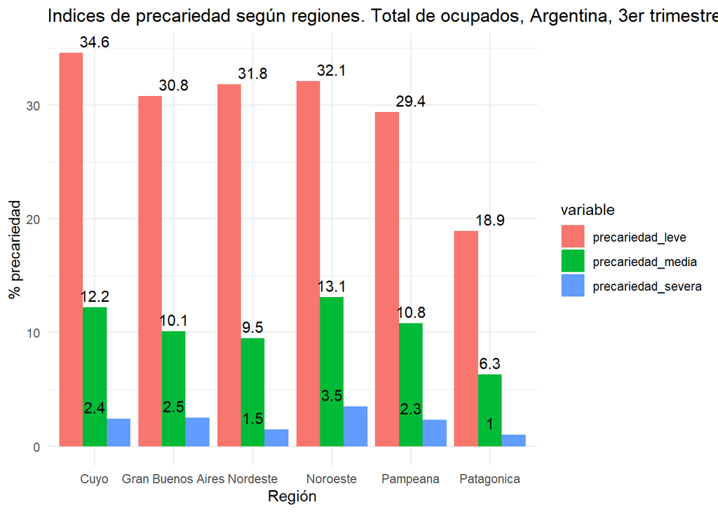

```r
##luego generamos con ello un gráfico de barras
graf_preca_regiones <- ggplot(proporciones_precariedad_region_long, aes(x = REGION, y = valor, fill = variable)) +
  geom_bar(stat = "identity", position = "dodge") +
  geom_text(aes(label = round(valor, 1)), vjust = -0.5) +
  labs(title = "Indices de precariedad según regiones. Total de ocupados, Argentina, 3er trimestre 2024",
       x = "Región",
       y = "% precariedad") +
  theme_minimal()

graf_preca_regiones
```

```r
ggsave("graf_preca_regiones.png", width = 8, height = 6)
```

## Resultados

### Generales

El primer resultado del análisis nos permite advertir una **tasa de precariedad del 43.5%**, total que se desagrega en **30.5% de precariedad leve** (un solo indicador), un **10.5% de precariedad media** (dos indicadores) y **2.5% de precariedad severa** (los tres indicadores presentes: informalidad, subocupación involuntaria y trabajo a término). Por su parte, al indagar estos datos en las diferentes regiones se advierten valores más altos de precariedad en las regiones de Noroeste (48.7%) y Cuyo (49.2%), siendo esta última región la que evidencia mayor precariedad leve, es decir, con sólo un indicador (34.6%), y la región Noroeste la que muestra el más alto índice de precariedad severa, esto es, con los tres indicadores (3.5%). A su vez, se destaca la región Patagonia con índices notoriamente más bajos de precariedad que el resto de las regiones, tanto en el total de precariedad (26.1%) como en sus variantes leve (18.9%), media (6.3%) y severa (1.0%).

“Tabla_precariedad_total.html”

“Tabla_precariedad_regiones.html”

“graf_preca_regiones.png”

Ahora bien, a estos índices entendemos conveniente complementarlos con el riesgo de precariedad (esto es, el cumplimiento de la doble condición de multiempleo y ocupación en establecimientos pequeños) entre la población no precaria. La proporción de quienes se encuentran en **riesgo de precariedad sobre la cantidad de trabajadores no precarios es de 2.9%**, siendo sensiblemente menor en la región Nordeste (2.1%) y Patagonia (1.0%).

“Tabla_riesgo_precariedad_regiones.html”

“graf_riesgo_prec_regiones.png”

```r
ocupados_2024_t3_no_preca <- ocupados_2024_t3_indicadores_prec_SIGNOS %>%
  filter (signos.precariedad == 0 ) %>% mutate(REGION = case_when(REGION  == 1   ~ "Gran Buenos Aires",
                                 REGION  == 40   ~ "Noroeste",
                                 REGION  == 41   ~ "Nordeste",
                                 REGION  == 42   ~ "Cuyo",
                                 REGION  == 43   ~ "Pampeana",
                                 REGION  == 44   ~ "Patagonica"))

ocupados_2024_t3_no_preca <- ocupados_2024_t3_no_preca %>%
    mutate(riesgo_precariedad = ifelse (tamanio.establec == "Pequeño" & multiempleo== "Multiempleo", "sí", "no"))


riesgo_precariedad <- calculate_tabulates(base = ocupados_2024_t3_no_preca, x = "riesgo_precariedad", y=
"REGION", weights = "PONDERA", add.totals="col")

riesgo_precariedad
```

```
## # A tibble: 2 × 8
##   riesgo_precariedad/REG…¹   Cuyo `Gran Buenos Aires` Nordeste Noroeste Pampeana
##   <fct>                     <int>               <int>    <int>    <int>    <int>
## 1 no                       408866             3981282   342257   613179  1598820
## 2 sí                        12140              125384     7360    18766    52004
## # ℹ abbreviated name: ¹`riesgo_precariedad/REGION`
## # ℹ 2 more variables: Patagonica <int>, Total <dbl>
```

```r
Riesgo_prec <- data.frame(
  Cuyo = c(408866, 12140),
  Gran_Buenos_Aires = c(3981282, 125384),
  Nordeste = c(342257, 7360),
  Noroeste = c(613179, 18766),
  Pampeana = c(1598820, 52004),
  Patagonica = c(346859, 3667),
  Total = c(7291263, 219321)
)

tasa_riesgo <- round(Riesgo_prec[2, ] / (Riesgo_prec[1, ] + Riesgo_prec[2, ]) * 100, 2)

Riesgo_prec <- rbind(Riesgo_prec, tasa_riesgo)

rownames(Riesgo_prec) <- c("Sin riesgo de precariedad", "Con riesgo de precariedad", "Tasa riesgo de precariedad")

Riesgo_prec_regional <- Riesgo_prec %>% slice(3)

Riesgo_prec_regional
```

```
##                            Cuyo Gran_Buenos_Aires Nordeste Noroeste Pampeana
## Tasa riesgo de precariedad 2.88              3.05     2.11     2.97     3.15
##                            Patagonica Total
## Tasa riesgo de precariedad       1.05  2.92
```

```r
## Guardamos la tabla con kable


Tabla_riesgo_precariedad_regiones <- kable(Riesgo_prec_regional, format = "html", caption = "Tabla 11: Riesgo de precariedad regional", align = 'c')

save_html(Tabla_riesgo_precariedad_regiones, file = "Tabla_riesgo_precariedad_regiones.html")

writeLines(as.character(Tabla_riesgo_precariedad_regiones), "tabla_clasificacion11.html")

Tabla_riesgo_precariedad_regiones
```

Tabla 11: Riesgo de precariedad regional

|  | Cuyo | Gran_Buenos_Aires | Nordeste | Noroeste | Pampeana | Patagonica | Total |
| --- | --- | --- | --- | --- | --- | --- | --- |
| Tasa riesgo de precariedad | 2.88 | 3.05 | 2.11 | 2.97 | 3.15 | 1.05 | 2.92 |

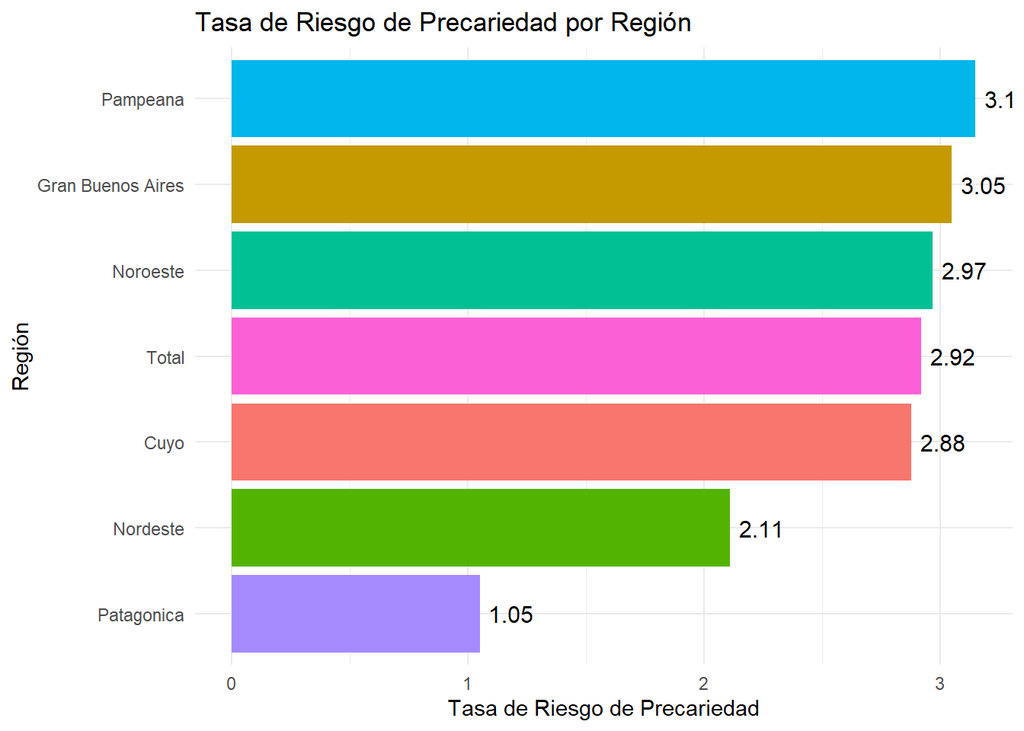

```r
##Graficamos con Ggplot

##Primero, creamos data frame limpio desde valores de la tabla
valores_riesgo_prec_region <- data.frame(
  Region = c("Cuyo", "Gran Buenos Aires", "Nordeste", "Noroeste", "Pampeana", "Patagonica", "Total"),
  Riesgo_Precariedad = c(2.88, 3.05, 2.11, 2.97, 3.15, 1.05, 2.92)
)

##Segundo, generamos el gráfico:

ggplot(valores_riesgo_prec_region, aes(x = reorder(Region, Riesgo_Precariedad), y = Riesgo_Precariedad, fill = Region)) +
  geom_col(show.legend = FALSE) +
  geom_text(aes(label = Riesgo_Precariedad),
            hjust = -0.2,
            size = 4) +
  coord_flip() +
  labs(title = "Tasa de Riesgo de Precariedad por Región",
       x = "Región",
       y = "Tasa de Riesgo de Precariedad") +
  theme_minimal()
```

```r
ggsave("graf_riesgo_prec_regiones.png", width = 8, height = 6)
```

### Precariedad agravada

Luego calculamos la incidencia de esos factores (multiempleo y ocupación en pequeños establecimientos) como agravantes de la condición de precariedad. En este caso, hemos considerado la presencia de uno u otro de ellos para dar lugar a la tasa de precariedad agravada. Así, hemos advertido que 7 de cada 10 trabajadores precarios cuentan con algún agravamiento de su condición precaria, sea por multiempleo u ocupación en establecimientos pequeños, sin evidenciar grandes diferencias en dicha proporción entre las diferentes regiones.

Tabla_precariedad_agravada_regiones.html

```r
ocupados_2024_t3_preca_agrav <- ocupados_2024_t3_indicadores_prec_SIGNOS %>%
  filter (signos.precariedad > 0 ) %>% mutate(REGION = case_when(REGION  == 1   ~ "Gran Buenos Aires",
                                 REGION  == 40   ~ "Noroeste",
                                 REGION  == 41   ~ "Nordeste",
                                 REGION  == 42   ~ "Cuyo",
                                 REGION  == 43   ~ "Pampeana",
                                 REGION  == 44   ~ "Patagonica"))

ocupados_2024_t3_preca_agrav <- ocupados_2024_t3_preca_agrav %>%
    mutate(precariedad_agravada = ifelse (tamanio.establec == "Pequeño" | multiempleo== "Multiempleo", "sí", "no"))


precariedad_agravada <- calculate_tabulates(base = ocupados_2024_t3_preca_agrav, x = "precariedad_agravada", y=
"REGION", weights = "PONDERA", add.totals="col")


Preca_agrav <- data.frame(
  Cuyo = c(103470, 274395),
  Gran_Buenos_Aires = c(942950, 1996493),
  Nordeste = c(62987, 168537),
  Noroeste = c(159116, 382322),
  Pampeana = c(298545, 841982),
  Patagonica = c(29524, 80194),
  Total = c(1596592, 3743923)
)

tasa_agrav <- round(Preca_agrav[2, ] / (Preca_agrav[1, ] + Preca_agrav[2, ]) * 100, 2)


tasa_agrav
```

```
##    Cuyo Gran_Buenos_Aires Nordeste Noroeste Pampeana Patagonica Total
## 2 72.62             67.92    72.79    70.61    73.82      73.09  70.1
```

```r
Preca_agrav <- rbind(Preca_agrav, tasa_agrav)

rownames(Preca_agrav) <- c("Sin precariedad agravada", "Con precariedad agravada", "Tasa de precariedad agravada")

Preca_agrav_regional <- Preca_agrav %>% slice(3)

Preca_agrav_regional
```

```
##                               Cuyo Gran_Buenos_Aires Nordeste Noroeste Pampeana
## Tasa de precariedad agravada 72.62             67.92    72.79    70.61    73.82
##                              Patagonica Total
## Tasa de precariedad agravada      73.09  70.1
```

```r
## Guardamos la tabla con kable


Tabla_precariedad_agrav_regiones <- kable(Preca_agrav_regional, format = "html", caption = "Tabla 12: Precariedad agravada regional", align = 'c')

save_html(Tabla_precariedad_agrav_regiones, file = "Tabla_precariedad_agravada_regiones.html")

writeLines(as.character(Tabla_precariedad_agrav_regiones), "tabla_clasificacion12.html")

Tabla_precariedad_agrav_regiones
```

Tabla 12: Precariedad agravada regional

|  | Cuyo | Gran_Buenos_Aires | Nordeste | Noroeste | Pampeana | Patagonica | Total |
| --- | --- | --- | --- | --- | --- | --- | --- |
| Tasa de precariedad agravada | 72.62 | 67.92 | 72.79 | 70.61 | 73.82 | 73.09 | 70.1 |

### Cruces por sexo, edad y nivel educativo

Finalmente, analizamos las tasas de precariedad según sexo, grupo etario y nivel educativo.

Primero, al contemplar la variable sexo advertimos una mayor tasa de precariedad entre las ocupadas mujeres (45.1%) que entre los varones (42.2%), lo cual a su vez se refleja en mayores índices de precariedad leve y media, en tanto los varones presentan una tasa de precariedad severa algo mayor que las mujeres (2.9% y 1.8%, respectivamente).

“Tabla_precariedad_sexo.html”

“graf_preca_sexo.png”

```r
#SEGUN SEXO

ocupados_2024_t3_precarios_sexo <- ocupados_2024_t3_indicadores_prec_SIGNOS %>%
  group_by(Sexo, signos.precariedad) %>%
  summarise(Poblacion = sum(PONDERA)) %>% ungroup()
ocupados_2024_t3_precarios_sexo
```

```
## # A tibble: 8 × 3
##   Sexo  signos.precariedad Poblacion
##   <chr>              <dbl>     <int>
## 1 Mujer                  0   3234250
## 2 Mujer                  1   1846275
## 3 Mujer                  2    701301
## 4 Mujer                  3    108131
## 5 Varón                  0   4323959
## 6 Varón                  1   2228574
## 7 Varón                  2    705266
## 8 Varón                  3    220284
```

```r
proporciones_precariedad_sexo <- ocupados_2024_t3_precarios_sexo %>% group_by(Sexo)  %>%
  summarise(proporcion_precarios = sum(Poblacion [signos.precariedad > 0]) / sum(Poblacion),
            precariedad_leve = sum(Poblacion[signos.precariedad == 1]) / sum(Poblacion),
            precariedad_media = sum(Poblacion[signos.precariedad == 2]) / sum(Poblacion),
            precariedad_severa = sum(Poblacion[signos.precariedad == 3]) / sum(Poblacion))

proporciones_precariedad_sexo
```

```
## # A tibble: 2 × 5
##   Sexo  proporcion_precarios precariedad_leve precariedad_media
##   <chr>                <dbl>            <dbl>             <dbl>
## 1 Mujer                0.451            0.313            0.119
## 2 Varón                0.422            0.298            0.0943
## # ℹ 1 more variable: precariedad_severa <dbl>
```

```r
##para expresarlo en porcentajes
proporciones_precariedad_sexo_x100 <- proporciones_precariedad_sexo %>%
  mutate(proporcion_precarios = round (proporcion_precarios * 100, 1), precariedad_leve = round (precariedad_leve * 100,1), precariedad_media = round(precariedad_media * 100, 1), precariedad_severa = round (precariedad_severa * 100, 1))

proporciones_precariedad_sexo_x100
```

```
## # A tibble: 2 × 5
##   Sexo  proporcion_precarios precariedad_leve precariedad_media
##   <chr>                <dbl>            <dbl>             <dbl>
## 1 Mujer                 45.1             31.3              11.9
## 2 Varón                 42.2             29.8               9.4
## # ℹ 1 more variable: precariedad_severa <dbl>
```

```r
##guardamos tabla con kabel

Tabla_prop_precariedad_sexo <- kable(proporciones_precariedad_sexo_x100, format = "html", caption = "Tabla 13: Precariedad según sexo", align = 'c')

save_html(Tabla_prop_precariedad_sexo, file = "Tabla_precariedad_sexo.html")

writeLines(as.character(Tabla_prop_precariedad_sexo), "tabla_clasificacion13.html")

Tabla_prop_precariedad_sexo
```

Tabla 13: Precariedad según sexo

| Sexo | proporcion_precarios | precariedad_leve | precariedad_media | precariedad_severa |
| --- | --- | --- | --- | --- |
| Mujer | 45.1 | 31.3 | 11.9 | 1.8 |
| Varón | 42.2 | 29.8 | 9.4 | 2.9 |

```r
##primero pasamos la tabla a modo largo con pivot longer

proporciones_precariedad_sexo_x100_long <- proporciones_precariedad_sexo_x100 %>%  pivot_longer(cols = starts_with("pr"),
               names_to = "variable",
               values_to = "valor")

print(proporciones_precariedad_sexo_x100_long)
```

```
## # A tibble: 8 × 3
##   Sexo  variable             valor
##   <chr> <chr>                <dbl>
## 1 Mujer proporcion_precarios  45.1
## 2 Mujer precariedad_leve      31.3
## 3 Mujer precariedad_media     11.9
## 4 Mujer precariedad_severa     1.8
## 5 Varón proporcion_precarios  42.2
## 6 Varón precariedad_leve      29.8
## 7 Varón precariedad_media      9.4
## 8 Varón precariedad_severa     2.9
```

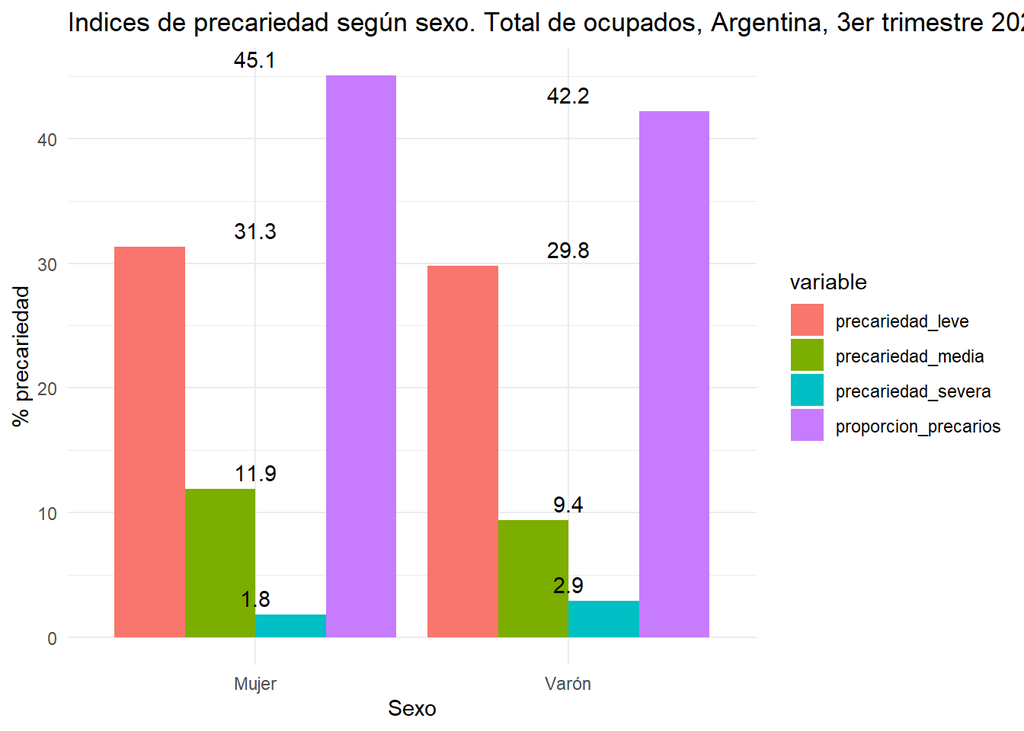

```r
graf_preca_sexo <- ggplot(proporciones_precariedad_sexo_x100_long, aes(x = Sexo, y = valor, fill = variable)) +
  geom_bar(stat = "identity", position = "dodge") +
  geom_text(aes(label = round(valor, 1)), vjust = -0.5) +
  labs(title = "Indices de precariedad según sexo. Total de ocupados, Argentina, 3er trimestre 2024",
       x = "Sexo",
       y = "% precariedad") +
  theme_minimal()

graf_preca_sexo
```

```r
ggsave("graf_preca_sexo.png", width = 8, height = 6)
```

“Tabla_precariedad_edad.html”

“graf_preca_edades.png”

```r
##SEGUN GRUPOS ETARIOS

ocupados_2024_t3_precarios_grupoet <- ocupados_2024_t3_indicadores_prec_SIGNOS %>%
  group_by(Grupos_Etarios, signos.precariedad) %>%
  summarise(Poblacion = sum(PONDERA)) %>% ungroup()
ocupados_2024_t3_precarios_grupoet
```

```
## # A tibble: 24 × 3
##    Grupos_Etarios         signos.precariedad Poblacion
##    <chr>                               <dbl>     <int>
##  1 Adultos Jóvenes                         0    562487
##  2 Adultos Jóvenes                         1    645687
##  3 Adultos Jóvenes                         2    339912
##  4 Adultos Jóvenes                         3     73327
##  5 Adultos Mayores                         0    434529
##  6 Adultos Mayores                         1    239435
##  7 Adultos Mayores                         2     37288
##  8 Adultos Mayores                         3      2052
##  9 Adultos mediana edad 1                  0   2494680
## 10 Adultos mediana edad 1                  1   1483413
## # ℹ 14 more rows
```

```r
## calculamos ahora las proporciones de esto:

proporciones_precariedad_grupoet <- ocupados_2024_t3_precarios_grupoet %>% group_by(Grupos_Etarios)  %>%
  summarise(proporcion_precarios = sum(Poblacion [signos.precariedad > 0]) / sum(Poblacion),
            precariedad_leve = sum(Poblacion[signos.precariedad == 1]) / sum(Poblacion),
            precariedad_media = sum(Poblacion[signos.precariedad == 2]) / sum(Poblacion),
            precariedad_severa = sum(Poblacion[signos.precariedad == 3]) / sum(Poblacion))

proporciones_precariedad_grupoet
```

```
## # A tibble: 6 × 5
##   Grupos_Etarios         proporcion_precarios precariedad_leve precariedad_media
##   <chr>                                 <dbl>            <dbl>             <dbl>
## 1 Adultos Jóvenes                       0.653            0.398            0.210
## 2 Adultos Mayores                       0.391            0.336            0.0523
## 3 Adultos mediana edad 1                0.463            0.319            0.110
## 4 Adultos mediana edad 2                0.376            0.273            0.0862
## 5 Adultos mediana edad 3                0.339            0.256            0.0696
## 6 Menores                               0.869            0.505            0.336
## # ℹ 1 more variable: precariedad_severa <dbl>
```

```r
##para expresarlo en porcentajes
proporciones_precariedad_grupoet_x100 <- proporciones_precariedad_grupoet %>%
  mutate(proporcion_precarios = round (proporcion_precarios * 100, 1), precariedad_leve = round (precariedad_leve * 100,1), precariedad_media = round(precariedad_media * 100, 1), precariedad_severa = round (precariedad_severa * 100, 1))

proporciones_precariedad_grupoet_x100
```

```
## # A tibble: 6 × 5
##   Grupos_Etarios         proporcion_precarios precariedad_leve precariedad_media
##   <chr>                                 <dbl>            <dbl>             <dbl>
## 1 Adultos Jóvenes                        65.3             39.8              21
## 2 Adultos Mayores                        39.1             33.6               5.2
## 3 Adultos mediana edad 1                 46.3             31.9              11
## 4 Adultos mediana edad 2                 37.6             27.3               8.6
## 5 Adultos mediana edad 3                 33.9             25.6               7
## 6 Menores                                86.9             50.5              33.6
## # ℹ 1 more variable: precariedad_severa <dbl>
```

```r
##guardamos tabla con kabel


Tabla_prop_precariedad_edad <- kable(proporciones_precariedad_grupoet_x100, format = "html", caption = "Tabla 14: Precariedad según grupos etarios", align = 'c')

save_html(Tabla_prop_precariedad_edad, file = "Tabla_precariedad_edad.html")
writeLines(as.character(Tabla_prop_precariedad_edad), "tabla_clasificacion14.html")

Tabla_prop_precariedad_edad
```

Tabla 14: Precariedad según grupos etarios

| Grupos_Etarios | proporcion_precarios | precariedad_leve | precariedad_media | precariedad_severa |
| --- | --- | --- | --- | --- |
| Adultos Jóvenes | 65.3 | 39.8 | 21.0 | 4.5 |
| Adultos Mayores | 39.1 | 33.6 | 5.2 | 0.3 |
| Adultos mediana edad 1 | 46.3 | 31.9 | 11.0 | 3.3 |
| Adultos mediana edad 2 | 37.6 | 27.3 | 8.6 | 1.7 |
| Adultos mediana edad 3 | 33.9 | 25.6 | 7.0 | 1.3 |
| Menores | 86.9 | 50.5 | 33.6 | 2.9 |

```r
##primero pasamos la tabla a modo largo con pivot longer

proporciones_precariedad_GE_100_long <- proporciones_precariedad_grupoet_x100 %>%  pivot_longer(cols = starts_with("pr"),
               names_to = "variable",
               values_to = "valor")

print(proporciones_precariedad_GE_100_long)
```

```
## # A tibble: 24 × 3
##    Grupos_Etarios         variable             valor
##    <chr>                  <chr>                <dbl>
##  1 Adultos Jóvenes        proporcion_precarios  65.3
##  2 Adultos Jóvenes        precariedad_leve      39.8
##  3 Adultos Jóvenes        precariedad_media     21
##  4 Adultos Jóvenes        precariedad_severa     4.5
##  5 Adultos Mayores        proporcion_precarios  39.1
##  6 Adultos Mayores        precariedad_leve      33.6
##  7 Adultos Mayores        precariedad_media      5.2
##  8 Adultos Mayores        precariedad_severa     0.3
##  9 Adultos mediana edad 1 proporcion_precarios  46.3
## 10 Adultos mediana edad 1 precariedad_leve      31.9
## # ℹ 14 more rows
```

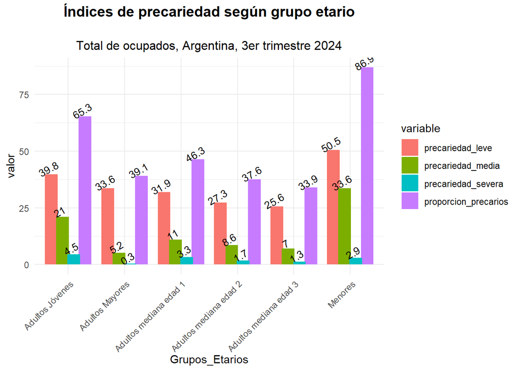

```r
graf_preca_edades <- ggplot(proporciones_precariedad_GE_100_long,
                            aes(x = Grupos_Etarios, y = valor, fill = variable)) +
  geom_bar(stat = "identity", position = position_dodge(width = 0.8)) +
  geom_text(aes(label = round(valor, 1)),
            position = position_dodge(width = 0.8),
            vjust = -0.3,
            size = 3.5,
            angle = 30) +
  ggtitle("Índices de precariedad según grupo etario\n",
          "Total de ocupados, Argentina, 3er trimestre 2024") +
  theme_minimal() +
  theme(plot.title = element_text(hjust = 0.5, size = 14, face = "bold"),
        plot.subtitle = element_text(hjust = 0.5, size = 12),
        axis.text.x = element_text(angle = 45, hjust = 1))

print(graf_preca_edades)
```

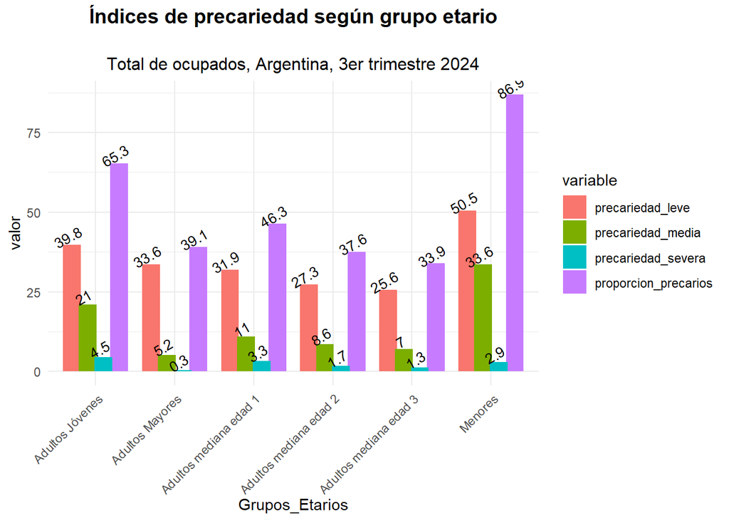

```r
graf_preca_edades
```

```r
ggsave("graf_preca_edades.png", width = 8, height = 6)
```

Finalmente, la consideración del nivel educativo muestra una cierta correlación entre nivel educativo alcanzado y tasas de precariedad, las cuales resultan especialmente bajas entre quienes completaron estudios superiores, tanto en la precariedad general (25.7%) como en la severa, donde tiende a reducirse significativamente (0.5%) respecto del resto.

“Tabla_precariedad_NE.html”

“graf_preca_NE.png”

```r
###SEGUN NIVEL EDUCATIVO


ocupados_2024_t3_precarios_NE <- ocupados_2024_t3_indicadores_prec_SIGNOS %>%
  group_by(Nivel_Educativo, signos.precariedad) %>%
  summarise(Poblacion = sum(PONDERA)) %>% ungroup()
ocupados_2024_t3_precarios_NE
```

```
## # A tibble: 28 × 3
##    Nivel_Educativo     signos.precariedad Poblacion
##    <chr>                            <dbl>     <int>
##  1 Primaria Completa                    0    601636
##  2 Primaria Completa                    1    485718
##  3 Primaria Completa                    2    200243
##  4 Primaria Completa                    3     69750
##  5 Primaria Incompleta                  0    149142
##  6 Primaria Incompleta                  1    128812
##  7 Primaria Incompleta                  2     58753
##  8 Primaria Incompleta                  3      8166
##  9 Secundaria Completa                  0   2176248
## 10 Secundaria Completa                  1   1320922
## # ℹ 18 more rows
```

```r
## calculamos ahora las proporciones de esto:

proporciones_precariedad_NE <- ocupados_2024_t3_precarios_NE %>% group_by(Nivel_Educativo)  %>%
  summarise(proporcion_precarios = sum(Poblacion [signos.precariedad > 0]) / sum(Poblacion),
            precariedad_leve = sum(Poblacion[signos.precariedad == 1]) / sum(Poblacion),
            precariedad_media = sum(Poblacion[signos.precariedad == 2]) / sum(Poblacion),
            precariedad_severa = sum(Poblacion[signos.precariedad == 3]) / sum(Poblacion))

proporciones_precariedad_NE
```

```
## # A tibble: 7 × 5
##   Nivel_Educativo        proporcion_precarios precariedad_leve precariedad_media
##   <chr>                                 <dbl>            <dbl>             <dbl>
## 1 Primaria Completa                     0.557            0.358            0.148
## 2 Primaria Incompleta                   0.568            0.374            0.170
## 3 Secundaria Completa                   0.459            0.328            0.108
## 4 Secundaria Incompleta                 0.598            0.390            0.161
## 5 Sin Instrucción                       0.424            0.333            0.0174
## 6 Superior Univ Completa                0.257            0.204            0.0477
## 7 Superior Univ Incompl…                0.426            0.301            0.106
## # ℹ 1 more variable: precariedad_severa <dbl>
```

```r
##para expresarlo en porcentajes
proporciones_precariedad_NE_x100 <- proporciones_precariedad_NE %>%
  mutate(proporcion_precarios = round (proporcion_precarios * 100, 1), precariedad_leve = round (precariedad_leve * 100,1), precariedad_media = round(precariedad_media * 100, 1), precariedad_severa = round (precariedad_severa * 100, 1))

proporciones_precariedad_NE_x100
```

```
## # A tibble: 7 × 5
##   Nivel_Educativo        proporcion_precarios precariedad_leve precariedad_media
##   <chr>                                 <dbl>            <dbl>             <dbl>
## 1 Primaria Completa                      55.7             35.8              14.8
## 2 Primaria Incompleta                    56.8             37.4              17
## 3 Secundaria Completa                    45.9             32.8              10.8
## 4 Secundaria Incompleta                  59.8             39                16.1
## 5 Sin Instrucción                        42.4             33.3               1.7
## 6 Superior Univ Completa                 25.7             20.4               4.8
## 7 Superior Univ Incompl…                 42.6             30.1              10.6
## # ℹ 1 more variable: precariedad_severa <dbl>
```

```r
##guardamos tabla con kabel


Tabla_prop_precariedad_NE <- kable(proporciones_precariedad_NE_x100, format = "html", caption = "Tabla 15: Precariedad según nivel educativo", align = 'c')

save_html(Tabla_prop_precariedad_NE, file = "Tabla_precariedad_NE.html")

writeLines(as.character(Tabla_prop_precariedad_NE), "tabla_clasificacion15.html")

Tabla_prop_precariedad_NE
```

Tabla 15: Precariedad según nivel educativo

| Nivel_Educativo | proporcion_precarios | precariedad_leve | precariedad_media | precariedad_severa |
| --- | --- | --- | --- | --- |
| Primaria Completa | 55.7 | 35.8 | 14.8 | 5.1 |
| Primaria Incompleta | 56.8 | 37.4 | 17.0 | 2.4 |
| Secundaria Completa | 45.9 | 32.8 | 10.8 | 2.4 |
| Secundaria Incompleta | 59.8 | 39.0 | 16.1 | 4.7 |
| Sin Instrucción | 42.4 | 33.3 | 1.7 | 7.4 |
| Superior Univ Completa | 25.7 | 20.4 | 4.8 | 0.5 |
| Superior Univ Incompleta | 42.6 | 30.1 | 10.6 | 1.9 |

```r
##primero pasamos la tabla a modo largo con pivot longer

proporciones_precariedad_NE_x100_long <- proporciones_precariedad_NE_x100 %>%  pivot_longer(cols = starts_with("pr"),
               names_to = "variable",
               values_to = "valor")

print(proporciones_precariedad_NE_x100_long)
```

```
## # A tibble: 28 × 3
##    Nivel_Educativo     variable             valor
##    <chr>               <chr>                <dbl>
##  1 Primaria Completa   proporcion_precarios  55.7
##  2 Primaria Completa   precariedad_leve      35.8
##  3 Primaria Completa   precariedad_media     14.8
##  4 Primaria Completa   precariedad_severa     5.1
##  5 Primaria Incompleta proporcion_precarios  56.8
##  6 Primaria Incompleta precariedad_leve      37.4
##  7 Primaria Incompleta precariedad_media     17
##  8 Primaria Incompleta precariedad_severa     2.4
##  9 Secundaria Completa proporcion_precarios  45.9
## 10 Secundaria Completa precariedad_leve      32.8
## # ℹ 18 more rows
```

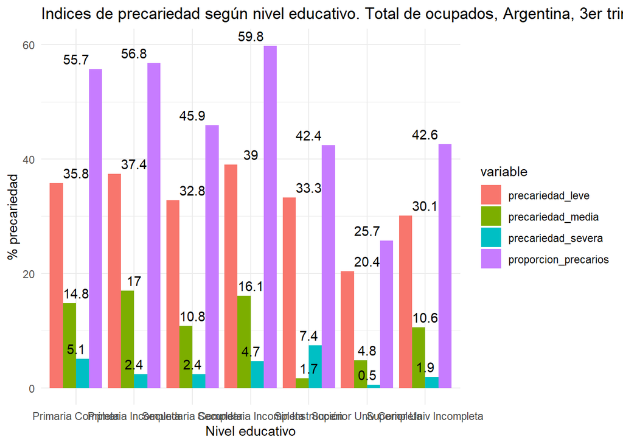

```r
graf_preca_NE <- ggplot(proporciones_precariedad_NE_x100_long, aes(x = Nivel_Educativo, y = valor, fill = variable)) +
  geom_bar(stat = "identity", position = "dodge") +
  geom_text(aes(label = round(valor, 1)), vjust = -0.5) +
  labs(title = "Indices de precariedad según nivel educativo. Total de ocupados, Argentina, 3er trimestre 2024",
       x = "Nivel educativo",
       y = "% precariedad") +
  theme_minimal()

graf_preca_NE
```

```r
ggsave("graf_preca_NE.png", width = 8, height = 6)
```

## Conclusiones

El mercado de trabajo se muestra fuertemente influido por el nivel de instrucción, encontrándose dos grandes umbrales en la educación secundaria y superior completas. Si bien la tasa de desocupación es relativamente baja en promedio, afecta especialmente al grupo de adultos más jóvenes, donde llega a triplicar los valores de otras franjas etarias. Asimismo, se muestra una marcada brecha de género en perjuicio de las mujeres respecto de la tasa de desocupación, más allá de las diferencias regionales en esta tasa, que en algunas regiones (Noroeste y Cuyo) se acerca a valores de pleno empleo.

Los factores de agravamiento considerados, por su parte, afectan a la gran mayoría de quienes se encuentran en condición de precariedad más allá de algunas leves diferencias regionales.